# GLMM Assignment

Elke

09-30-2024

### **Objective**

Create a report using Markdown that presents code, results, and summarized findings that makes inference to the occurence of the Annamite striped rabbit (*Nesolagus timminsi*) across multiple protected areas in Vietnam.

### **Background**

This is not real data. However, the basic premise has been adopted from the paper, [Getting the big picture: Landscape-scale occupancy patterns of two Annamite endemics among multiple protected areas](https://conbio.onlinelibrary.wiley.com/doi/full/10.1111/csp2.620).

### **Overview**

The Annamite striped rabbit is a forest-dwelling lagomorph that was discovered by science in the mid-1990s. Little is known about this species. What has been done indicates that hunting pressure is a primary driver of its distribution. As such, protected areas are paramount to their conservation. However, protected areas vary in their effectiveness in limiting hunting and some protected areas are founded on multi-use, such that hunting is still allowed.

[figure not shown]

# Exploring data

```r
# Creating Data set

rabbitdata = read.csv("rabbit.occ.data.csv")

# Explore

summary(rabbitdata)
```

```
##        X               PA                camera         occur
##  Min.   :  1.00   Length:250         Min.   : 1.0   Min.   :0.000
##  1st Qu.: 63.25   Class :character   1st Qu.:13.0   1st Qu.:0.000
##  Median :125.50   Mode  :character   Median :25.5   Median :1.000
##  Mean   :125.50                      Mean   :25.5   Mean   :0.572
##  3rd Qu.:187.75                      3rd Qu.:38.0   3rd Qu.:1.000
##  Max.   :250.00                      Max.   :50.0   Max.   :1.000
##    dist.human
##  Min.   :  19.33
##  1st Qu.:1343.90
##  Median :2565.12
##  Mean   :2545.85
##  3rd Qu.:3819.24
##  Max.   :5052.65
```

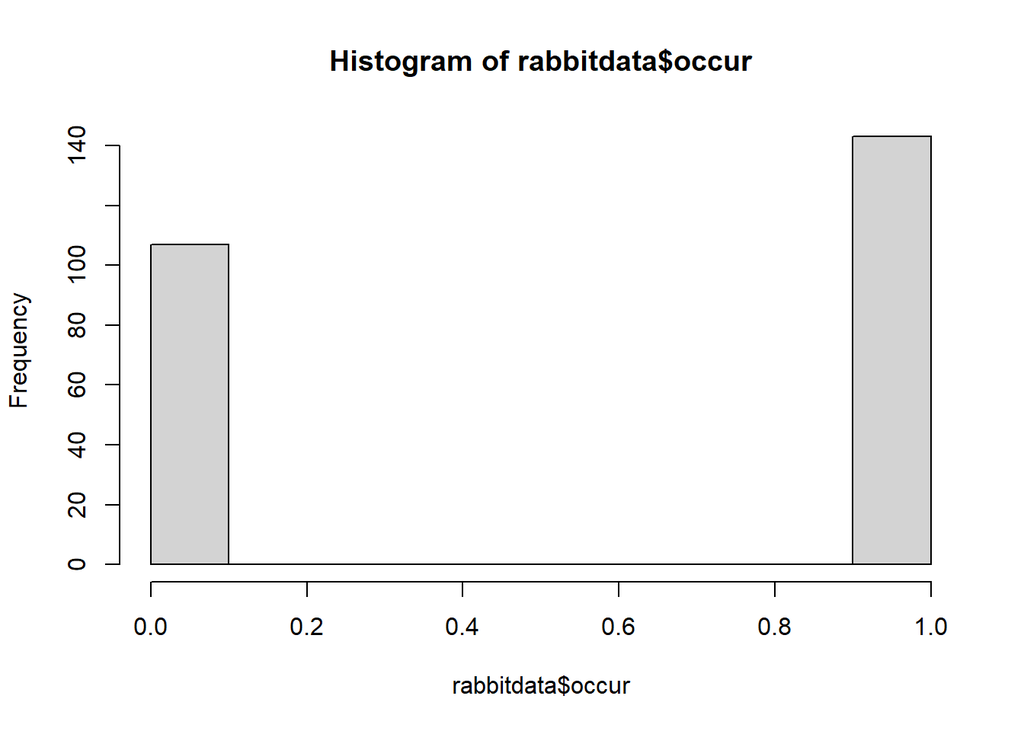

```r
hist(rabbitdata$occur)
```

```r
str(rabbitdata)
```

```
## 'data.frame':    250 obs. of  5 variables:
##  $ X         : int  1 2 3 4 5 6 7 8 9 10 ...
##  $ PA        : chr  "PA1" "PA1" "PA1" "PA1" ...
##  $ camera    : int  1 2 3 4 5 6 7 8 9 10 ...
##  $ occur     : int  0 0 0 0 0 0 0 0 0 1 ...
##  $ dist.human: num  140 188 363 408 504 ...
```